# Decision Trees Practical

Njenga Gakwa

2026-04-11

### Libraries required

```r
library(tidyverse)
library(tree)
library(randomForest)
```

Load the data

```r
# Load the data

load("youth_data.RData")
```

Explore the data with question “How do demographic and household factors influence youth substance use and its frequency?”

### Cleaning the dataset

Filter out the required variables to help find insights to the question and ensure the variables are appropriate for modeling.

```r
mini_df <- df %>%
  mutate(

    # Y-variables
    ALCFLAG = factor(ALCFLAG),
    MRJYDAYS = factor(MRJYDAYS),

    # Regression target cleanup
    IRCIGFM = ifelse(IRCIGFM <= 30, as.numeric(IRCIGFM),
                ifelse(IRCIGFM %in% c(91, 93), 0, NA)),

    # convert demographics to factors
    IRSEX = factor(IRSEX),
    NEWRACE2 = factor(NEWRACE2),
    INCOME = factor(INCOME),
    POVERTY3 = factor(POVERTY3),
    EDUSCHGRD2 = factor(EDUSCHGRD2),
    EDUSCHLGO = factor(EDUSCHLGO),
    IMOTHER = factor(IMOTHER),
    IFATHER = factor(IFATHER),
    GOVTPROG = factor(GOVTPROG),
    PDEN10 = factor(PDEN10),
    COUTYP4 = factor(COUTYP4),

    # Numeric
    EDUSKPCOM = as.numeric(EDUSKPCOM)
  ) %>%
  drop_na()
```

#### Train / Test splits

```r
set.seed(123)

n <- nrow(mini_df)

index <- sample(1:n, n * 0.8)
train <- mini_df[index, ]
test <- mini_df[- index, ]
```

## Models

### Binary Classification

Utilizing the Alcohol variable, create a tree, plot for visualization, and evaluate the performance on the test data

```r
dem_tree <- tree(ALCFLAG ~ IRSEX + NEWRACE2 + INCOME + POVERTY3 +
                   EDUSCHGRD2 + EDUSCHLGO + EDUSKPCOM +
                   IMOTHER + IFATHER + GOVTPROG +
                   PDEN10 + COUTYP4,
                 data = train)

summary(dem_tree)
```

```
##
## Classification tree:
## tree(formula = ALCFLAG ~ IRSEX + NEWRACE2 + INCOME + POVERTY3 +
##     EDUSCHGRD2 + EDUSCHLGO + EDUSKPCOM + IMOTHER + IFATHER +
##     GOVTPROG + PDEN10 + COUTYP4, data = train)
## Variables actually used in tree construction:
## [1] "EDUSCHGRD2"
## Number of terminal nodes:  3
## Residual mean deviance:  1.05 = 6928 / 6596
## Misclassification error rate: 0.2487 = 1641 / 6599
```

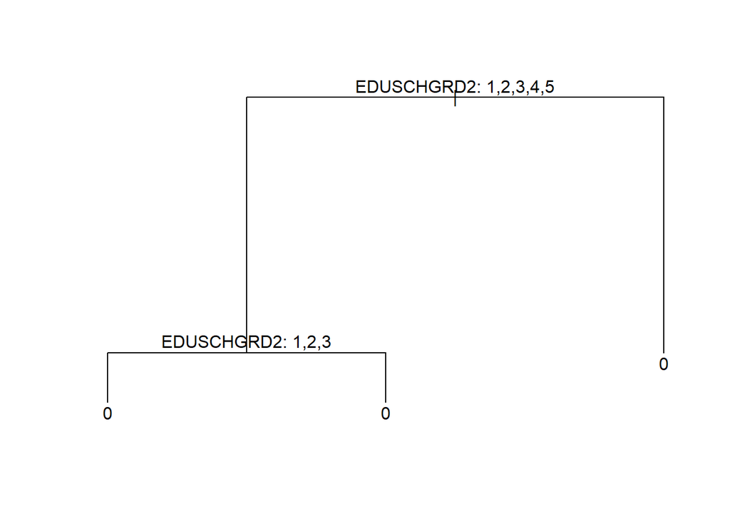

```r
plot(dem_tree)
text(dem_tree, pretty = 0)
```

```r
dem_tree
```

```
## node), split, n, deviance, yval, (yprob)
##       * denotes terminal node
##
## 1) root 6599 7402.0 0 ( 0.75133 0.24867 )
##   2) EDUSCHGRD2: 1,2,3,4,5 2986 2359.0 0 ( 0.86537 0.13463 )
##     4) EDUSCHGRD2: 1,2,3 995  458.8 0 ( 0.93869 0.06131 ) *
##     5) EDUSCHGRD2: 4,5 1991 1823.0 0 ( 0.82873 0.17127 ) *
##   3) EDUSCHGRD2: 6,7,8,9,10,98,99 3613 4646.0 0 ( 0.65707 0.34293 ) *
```

The classification tree identifies school grade level (EDUSCHGRD2) as the only variable used to predict alcohol use, highlighting its importance among demographic factors. The model splits students into three groups: younger students in grades 1–3, intermediate students in grades 4–5, and older students in grades 6–10. The probability of alcohol use increases steadily across these groups, with the youngest students showing very low usage rates (about 6%), middle grades showing moderate usage (about 17%), and older students showing the highest likelihood (about 34%). Although the model captures a clear trend between age and alcohol use, the overall misclassification error rate of about 24.9% indicates that demographic variables alone provide only moderate predictive power.

Prune the tree then evaluate the test data on the pruned tree

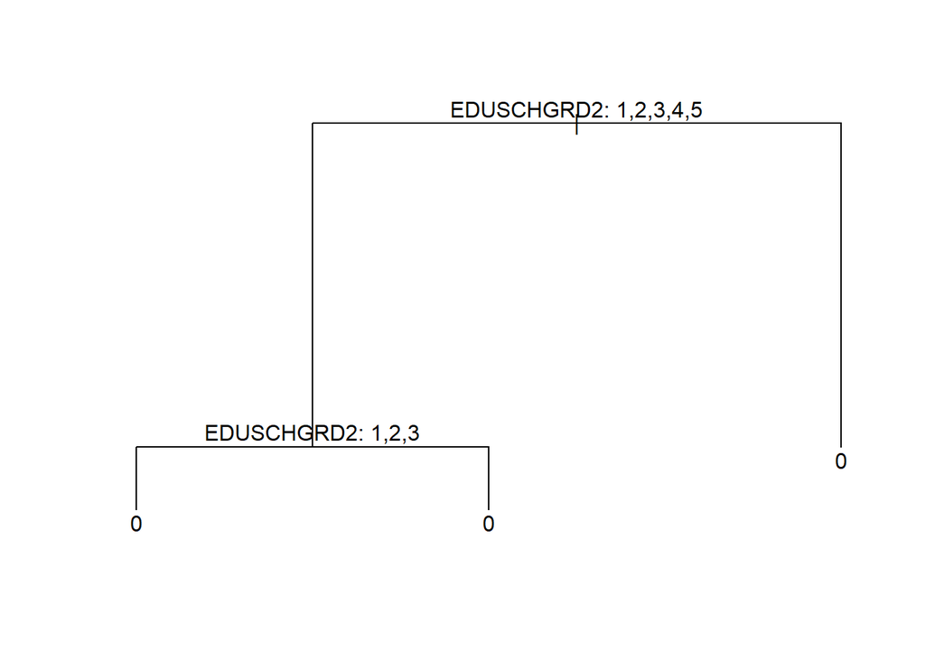

```r
cv_tree <- cv.tree(dem_tree, FUN = prune.misclass)

best_size <- cv_tree$size[which.min(cv_tree$dev)]

pruned_tree <- prune.misclass(dem_tree, best = best_size)

plot(pruned_tree)
text(pruned_tree, pretty = 0)
```

```r
pruned_tree
```

```
## node), split, n, deviance, yval, (yprob)
##       * denotes terminal node
##
## 1) root 6599 7402.0 0 ( 0.75133 0.24867 )
##   2) EDUSCHGRD2: 1,2,3,4,5 2986 2359.0 0 ( 0.86537 0.13463 )
##     4) EDUSCHGRD2: 1,2,3 995  458.8 0 ( 0.93869 0.06131 ) *
##     5) EDUSCHGRD2: 4,5 1991 1823.0 0 ( 0.82873 0.17127 ) *
##   3) EDUSCHGRD2: 6,7,8,9,10,98,99 3613 4646.0 0 ( 0.65707 0.34293 ) *
```

Evaluating the test data we get

```r
dem_pred <- predict(pruned_tree, test, type = "class")

table(dem_pred, test$ALCFLAG)
```

```
##
## dem_pred    0    1
##        0 1241  409
##        1    0    0
```

The confusion matrix shows that the model predicts only the majority class (no alcohol use) for all observations. This results in an accuracy of approximately 75%, but the model fails to identify any instances of alcohol use. This behavior reflects class imbalance in the dataset, where most youth report not using alcohol, as well as the limited predictive power of demographic variables alone.

### Bagging

```r
bag_model <- randomForest(
  ALCFLAG ~ IRSEX + NEWRACE2 + INCOME + POVERTY3 +
    EDUSCHGRD2 + EDUSCHLGO + EDUSKPCOM +
    IMOTHER + IFATHER + GOVTPROG +
    PDEN10 + COUTYP4,

  data = train,
  ntree = 300,
  mtry = 12,
  importance = TRUE
)

bag_pred <- predict(bag_model, test)

mean(bag_pred == test$ALCFLAG)
```

```
## [1] 0.7109091
```

```r
table(bag_pred,test$ALCFLAG)
```

```
##
## bag_pred    0    1
##        0 1091  327
##        1  150   82
```

While it’s more complex than the single tree, it performs worse than a blind guess. The accuracy is approximately 71%, which is lower than the 75% baseline. Looking at the confusion matrix, the model is struggling to identify drinkers as it missed roughly 80% of the actual drinkers in the test set.

### Random Forest Binary

```r
dem_rf <- randomForest(
  ALCFLAG ~ IRSEX + NEWRACE2 + INCOME + POVERTY3 +
    EDUSCHGRD2 + EDUSCHLGO + EDUSKPCOM +
    IMOTHER + IFATHER + GOVTPROG +
    PDEN10 + COUTYP4,

  data = train,
  importance = TRUE
)



rf_pred <- predict(dem_rf, test)

table(rf_pred,test$ALCFLAG)
```

```
##
## rf_pred    0    1
##       0 1189  366
##       1   52   43
```

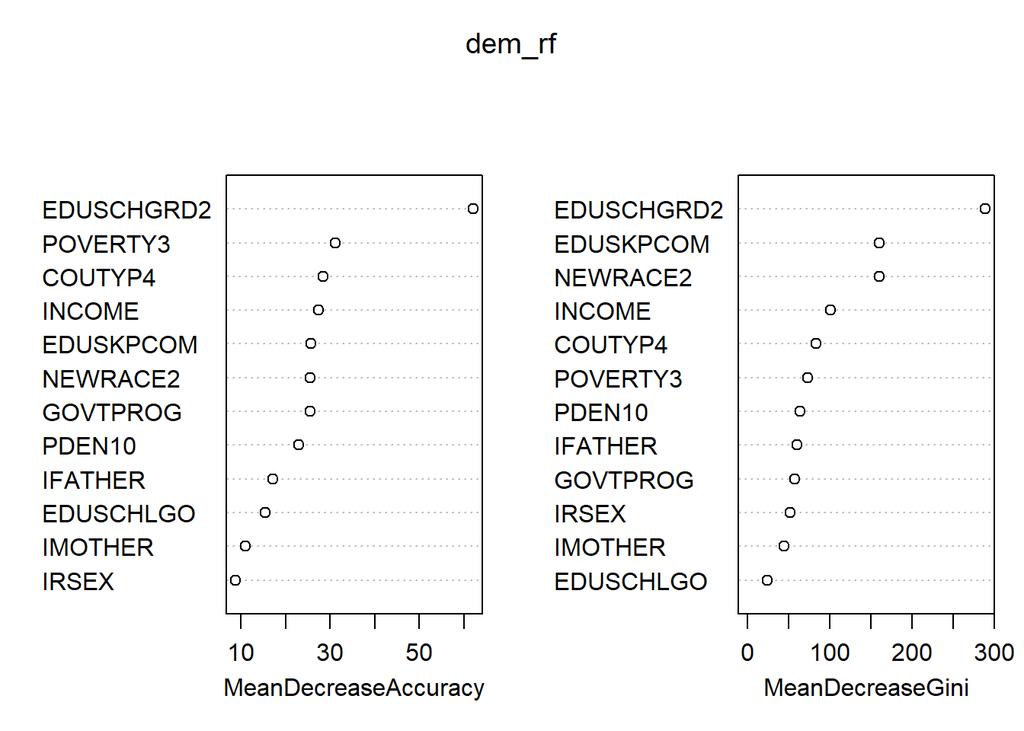

```r
varImpPlot(dem_rf)
```

These plots identify which features most influence the random forest model’s decisions. EDUSCHGRD2, which represents the respondent’s level of education, is the top predictor in both charts by a considerable margin, meaning it has the strongest impact on predicting alcohol use. Variables like POVERTY3, COUTYP4, and INCOME provide solid secondary value, whereas features at the bottom such as IMOTHER and IRSEX have very little influence on the outcome.

### Multi-class Marijuana Use

```r
rf_multi <- randomForest(
  MRJYDAYS ~ IRSEX + NEWRACE2 + INCOME + POVERTY3 +
    EDUSCHGRD2 + EDUSCHLGO + EDUSKPCOM +
    IMOTHER + IFATHER + GOVTPROG +
    PDEN10 + COUTYP4,

  data = train,
  ntree = 300
)

multi_pred <- predict(rf_multi, test)

mean(multi_pred == test$MRJYDAYS)
```

```
## [1] 0.8660606
```

```r
table(multi_pred, test$MRJYDAYS)
```

```
##
## multi_pred    1    2    3    4    5    6
##          1    0    0    0    0    0    0
##          2    0    0    0    0    0    0
##          3    0    0    0    0    0    0
##          4    0    0    0    0    0    0
##          5    0    0    0    0    0    0
##          6   69   47   26   54   25 1429
```